# SETUP-System-For-Colab

## Copy Files from GDRIVE

```python
from google.colab import drive
drive.mount('/content/drive')
!git clone https://github.com/cocodataset/cocoapi.git
maketext="""
all:
    # install pycocotools locally
	python3 setup.py build_ext --inplace
	rm -rf build

install:
	# install pycocotools to the Python site-packages
	python3 setup.py build_ext install
	rm -rf build
"""
print(maketext, file=open('/content/cocoapi/PythonAPI/Makefile', 'w'))
setuptxt="""
from setuptools import setup, Extension
import numpy as np

# To compile and install locally run "python setup.py build_ext --inplace"
# To install library to Python site-packages run "python setup.py build_ext install"

ext_modules = [
    Extension(
        'pycocotools._mask',
        sources=['../common/maskApi.c', 'pycocotools/_mask.pyx'],
        #sources=['common/maskApi.c'],
        include_dirs = [np.get_include(), '../common'],
        #extra_compile_args=['-Wno-cpp', '-Wno-unused-function', '-std=c99'],
        extra_compile_args=['-std=c99'],
    )
]

setup(
    name='pycocotools',
    packages=['pycocotools'],
    package_dir = {'pycocotools': 'pycocotools'},
    install_requires=[
        'setuptools>=18.0',
        'cython>=0.27.3',
        'matplotlib>=2.1.0'
    ],
    version='2.0',
    ext_modules= ext_modules
)
"""
print(setuptxt, file=open('/content/cocoapi/PythonAPI/setup.py', 'w'))
!cd /content/cocoapi/PythonAPI; make; make install
!mkdir /content/cocoapi/images/
!mkdir /content/cocoapi/annotations/
!mkdir models
!cp /content/drive/MyDrive/_Colab/CV-Image_Captioning/*.py /content/
!cp /content/drive/MyDrive/_Colab/CV-Image_Captioning/cocoapi/images/*.zip /content/
!cp /content/drive/MyDrive/_Colab/CV-Image_Captioning/cocoapi/annotations/*.zip /content/
!cp /content/drive/MyDrive/_Colab/CV-Image_Captioning/models/* /content/models/
!unzip /content/train2014.zip -d /content/cocoapi/images/
!unzip /content/test2014.zip  -d /content/cocoapi/images/
!unzip /content/val2014.zip  -d /content/cocoapi/images/
!unzip /content/annotations_trainval2014.zip  -d /content/cocoapi/annotations/
!unzip /content/image_info_test2014.zip -d /content/cocoapi/annotations/
!mv /content/cocoapi/annotations/annotations/* /content/cocoapi/annotations/
!rm -rf /content/cocoapi/annotations/annotations
!rm /content/train2014.zip
!rm /content/test2014.zip
!rm /content/val2014.zip
!rm /content/annotations_trainval2014.zip
!rm /content/image_info_test2014.zip
!pip install nltk
import nltk
nltk.download('punkt')
```

## Get From GDrive Smaller DB

```python
from google.colab import drive
drive.mount('/content/drive')
!git clone https://github.com/cocodataset/cocoapi.git
maketext="""
all:
    # install pycocotools locally
	python3 setup.py build_ext --inplace
	rm -rf build

install:
	# install pycocotools to the Python site-packages
	python3 setup.py build_ext install
	rm -rf build
"""
print(maketext, file=open('/content/cocoapi/PythonAPI/Makefile', 'w'))
setuptxt="""
from setuptools import setup, Extension
import numpy as np

# To compile and install locally run "python setup.py build_ext --inplace"
# To install library to Python site-packages run "python setup.py build_ext install"

ext_modules = [
    Extension(
        'pycocotools._mask',
        sources=['../common/maskApi.c', 'pycocotools/_mask.pyx'],
        #sources=['common/maskApi.c'],
        include_dirs = [np.get_include(), '../common'],
        #extra_compile_args=['-Wno-cpp', '-Wno-unused-function', '-std=c99'],
        extra_compile_args=['-std=c99'],
    )
]

setup(
    name='pycocotools',
    packages=['pycocotools'],
    package_dir = {'pycocotools': 'pycocotools'},
    install_requires=[
        'setuptools>=18.0',
        'cython>=0.27.3',
        'matplotlib>=2.1.0'
    ],
    version='2.0',
    ext_modules= ext_modules
)
"""
print(setuptxt, file=open('/content/cocoapi/PythonAPI/setup.py', 'w'))
!cd /content/cocoapi/PythonAPI; make; make install
!mkdir /content/cocoapi/images/
!mkdir /content/cocoapi/annotations/
!mkdir models
!cp /content/drive/MyDrive/_Colab/CV-Image_Captioning/*.py /content/
!cp /content/drive/MyDrive/_Colab/*_small.zip /content/
!cp /content/drive/MyDrive/_Colab/CV-Image_Captioning/models/* /content/models/
!unzip /content/train2014_small.zip -d /content/cocoapi/images/
!unzip /content/test2014_small.zip  -d /content/cocoapi/images/
!unzip /content/val2014_small.zip  -d /content/cocoapi/images/
!unzip /content/annotations_trainval2014_small.zip  -d /content/cocoapi/annotations/
!unzip /content/annotations_small.zip -d /content/cocoapi/annotations/
!mv /content/cocoapi/annotations/annotations/* /content/cocoapi/annotations/
!rm -rf /content/cocoapi/annotations/annotations
!rm /content/train2014_small.zip
!rm /content/test2014_small.zip
!rm /content/val2014_small.zip
!rm /content/annotations_small.zip
!pip install nltk
import nltk
nltk.download('punkt')
```

# Computer Vision Nanodegree

## Project: Image Captioning

In this notebook, you will use your trained model to generate captions for images in the test dataset.

This notebook **will be graded**.

Feel free to use the links below to navigate the notebook:

- Step 1: Get Data Loader for Test Dataset
- Step 2: Load Trained Models
- Step 3: Finish the Sampler
- Step 4: Clean up Captions
- Step 5: Generate Predictions!

## Step 1: Get Data Loader for Test Dataset

Before running the code cell below, define the transform in `transform_test` that you would like to use to pre-process the test images.

Make sure that the transform that you define here agrees with the transform that you used to pre-process the training images (in **2_Training.ipynb**). For instance, if you normalized the training images, you should also apply the same normalization procedure to the test images.

```python
import sys
sys.path.append('cocoapi/PythonAPI')
from pycocotools.coco import COCO
from data_loader import get_loader
from torchvision import transforms

# TODO #1: Define a transform to pre-process the testing images.
# Using same as training
transform_test = transforms.Compose([
    transforms.Resize(256),                          # smaller edge of image resized to 256
    transforms.RandomCrop(224),                      # get 224x224 crop from random location
    #transforms.RandomHorizontalFlip(0.5),               # horizontally flip image with probability=0.5
    transforms.ToTensor(),                           # convert the PIL Image to a tensor
    transforms.Normalize((0.485, 0.456, 0.406),      # normalize image for pre-trained model
                         (0.229, 0.224, 0.225))])

#-#-#-# Do NOT modify the code below this line. #-#-#-#

# Create the data loader.
data_loader = get_loader(transform=transform_test,
                         mode='test', cocoapi_loc='', vocab_file='vocab_complete_training_thr3.pkl')
```

```
Vocabulary successfully loaded from vocab.pkl file!
```

Run the code cell below to visualize an example test image, before pre-processing is applied.

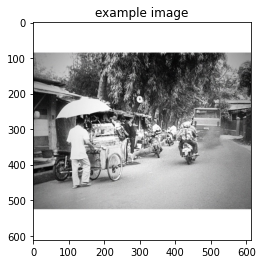

```python
import numpy as np
import matplotlib.pyplot as plt
%matplotlib inline

# Obtain sample image before and after pre-processing.
orig_image, image = next(iter(data_loader))

# Visualize sample image, before pre-processing.
plt.imshow(np.squeeze(orig_image))
plt.title('example image')
plt.show()
```

## Step 2: Load Trained Models

In the next code cell we define a `device` that you will use move PyTorch tensors to GPU (if CUDA is available). Run this code cell before continuing.

```python
import torch

device = torch.device("cuda" if torch.cuda.is_available() else "cpu")
```

Before running the code cell below, complete the following tasks.

### Task #1

In the next code cell, you will load the trained encoder and decoder from the previous notebook (**2_Training.ipynb**). To accomplish this, you must specify the names of the saved encoder and decoder files in the `models/` folder (e.g., these names should be `encoder-5.pkl` and `decoder-5.pkl`, if you trained the model for 5 epochs and saved the weights after each epoch).

### Task #2

Plug in both the embedding size and the size of the hidden layer of the decoder corresponding to the selected pickle file in `decoder_file`.

```python
# Watch for any changes in model.py, and re-load it automatically.
% load_ext autoreload
% autoreload 2

import os
import torch
from model import EncoderCNN, DecoderRNNv102

# TODO #2: Specify the saved models to load.
run_key = 'v102_paramsDecoder_withoutFlipTrans_batch_size10_vocabThr3_embedSize512_hiddenSize1024_totEpochs10'

epoch = 5
encoder_file = run_key + f'encoder-{epoch}.pkl'
decoder_file = run_key + f'decoder-{epoch}.pkl'

# TODO #3: Select appropriate values for the Python variables below.
embed_size = int(encoder_file[encoder_file.find('_embedSize')+10:encoder_file.find('_hiddenSize')])
hidden_size = int(encoder_file[encoder_file.find('_hiddenSize')+11:encoder_file.find('_totEpochs')])

# The size of the vocabulary.
vocab_size = len(data_loader.dataset.vocab)

# Initialize the encoder and decoder, and set each to inference mode.
encoder = EncoderCNN(embed_size)
encoder = encoder.cpu()
encoder.eval()
decoder = DecoderRNNv102(embed_size, hidden_size, vocab_size)
decoder = decoder.cpu()
decoder.eval()

# Load the trained weights.
encoder.load_state_dict(torch.load(os.path.join('./models', encoder_file), map_location=torch.device('cpu')))
decoder.load_state_dict(torch.load(os.path.join('./models', decoder_file), map_location=torch.device('cpu')))

# Move models to GPU if CUDA is available.
encoder.to(device)
decoder.to(device)
```

```
The autoreload extension is already loaded. To reload it, use:
  %reload_ext autoreload
```

```
DecoderRNNv102(
  (embedding): Embedding(11498, 512)
  (lstm): LSTM(512, 1024, batch_first=True)
  (linear): Linear(in_features=1024, out_features=11498, bias=True)
)
```

## Step 3: Finish the Sampler

Before executing the next code cell, you must write the `sample` method in the `DecoderRNN` class in **model.py**. This method should accept as input a PyTorch tensor `features` containing the embedded input features corresponding to a single image.

It should return as output a Python list `output`, indicating the predicted sentence. `output[i]` is a nonnegative integer that identifies the predicted `i`-th token in the sentence. The correspondence between integers and tokens can be explored by examining either `data_loader.dataset.vocab.word2idx` (or `data_loader.dataset.vocab.idx2word`).

After implementing the `sample` method, run the code cell below. If the cell returns an assertion error, then please follow the instructions to modify your code before proceeding. Do **not** modify the code in the cell below.

```python
# Move image Pytorch Tensor to GPU if CUDA is available.
image = image.to(device)

# Obtain the embedded image features.
features = encoder(image).unsqueeze(1)

# Pass the embedded image features through the model to get a predicted caption.
output = decoder.sample(features)
print('example output:', output)

assert (type(output)==list), "Output needs to be a Python list"
assert all([type(x)==int for x in output]), "Output should be a list of integers."
assert all([x in data_loader.dataset.vocab.idx2word for x in output]), "Each entry in the output needs to correspond to an integer that indicates a token in the vocabulary."
```

```
example output: [0, 3, 80, 13, 51, 171, 193, 3, 175, 18, 1]
```

## Step 4: Clean up the Captions

In the code cell below, complete the `clean_sentence` function. It should take a list of integers (corresponding to the variable `output` in **Step 3**) as input and return the corresponding predicted sentence (as a single Python string).

```python
# TODO #4: Complete the function.
def clean_sentence(data_loader, output):
    sentence = [data_loader.dataset.vocab.idx2word[f] for f in output]
    if sentence[0] != data_loader.dataset.vocab.start_word or sentence[-1] != data_loader.dataset.vocab.end_word:
      print('incorrect starting/ending sentence')
      return
    sentence = sentence[1:-1]
    #end of line
    if sentence[-1] in '!.?...…':  sentence=" ".join(sentence[:-1]) + sentence[-1]
    else: sentence=" ".join(sentence)
    return sentence
```

After completing the `clean_sentence` function above, run the code cell below. If the cell returns an assertion error, then please follow the instructions to modify your code before proceeding.

```python
sentence = clean_sentence(data_loader, output)
print('example sentence:', sentence)

assert type(sentence)==str, 'Sentence needs to be a Python string!'
```

```
example sentence: a group of people standing around a bus.
```

## Step 5: Generate Predictions!

In the code cell below, we have written a function (`get_prediction`) that you can use to use to loop over images in the test dataset and print your model's predicted caption.

```python
def get_prediction():
    orig_image, image = next(iter(data_loader))
    plt.imshow(np.squeeze(orig_image))
    plt.title('Sample Image')
    plt.show()
    image = image.to(device)
    features = encoder(image).unsqueeze(1)
    output = decoder.sample(features)
    sentence = clean_sentence(data_loader, output)
    print(sentence)
```

Run the code cell below (multiple times, if you like!) to test how this function works.

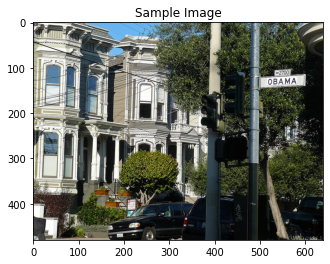

```
a street sign on a pole on a street.
```

```python
get_prediction()
```

As the last task in this project, you will loop over the images until you find four image-caption pairs of interest:

- Two should include image-caption pairs that show instances when the model performed well.
- Two should highlight image-caption pairs that highlight instances where the model did not perform well.

Use the four code cells below to complete this task.

### The model performed well!

Use the next two code cells to loop over captions. Save the notebook when you encounter two images with relatively accurate captions.

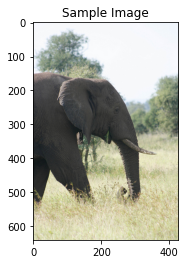

```
a large elephant standing in a field.
```

```python
get_prediction()
```

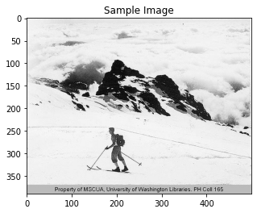

```
a person riding skis down a snow covered slope.
```

```python
get_prediction()
```

### The model could have performed better ...

Use the next two code cells to loop over captions. Save the notebook when you encounter two images with relatively inaccurate captions.

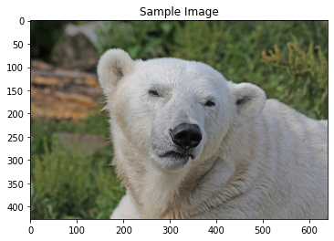

```
a white and brown bear is standing in a field.
```

```python
get_prediction()
```

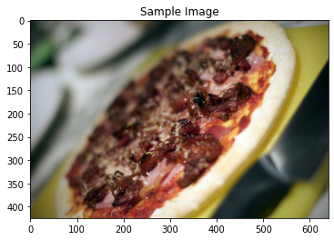

```
a pizza with cheese and spinach on it.
```

```python
get_prediction()
```

### The model didn't perform so well ...

Use the next two code cells to loop over captions. Save the notebook when you encounter two images with relatively inaccurate captions.

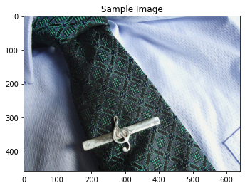

```
a pair of scissors sitting on top of a table.
```

```python
get_prediction()
```